# IE360: Homework 2

Barış Arslan 2019402129

11/5/2022

## Required Packages

```r
library(readr)
library(dplyr)
library(urca)
library(data.table)
library(forecast)
library(ggplot2)
library(GGally)
library(corrplot)
library(zoo)
library(lubridate)
```

## 1. Introduction

In the Homework 2 of IE360: Statistical Forecasting and Time Series course, the ultimate task is to forecast the sales of UGS for every quarter of 2007 by using time series regression methods.

Here are the first and last six rows of the data:

```
##   Quarter     UGS   RNUV   NLPG     PU     PG    NUGV     NDGV    GNPA    GNPC
## 1 2000 Q1 1128971 0.0146 940000 469.03 355.69 4647500 281.9853 1040173 3483132
## 2 2000 Q2 1199569 0.0205 941000 459.42 344.58 4742876 284.0813 1760460 4525451
## 3 2000 Q3 1370167 0.0207 943500 439.98 327.21 4840931 286.7169 6974808 5915204
## 4 2000 Q4 1127548 0.0163 948000 402.08 300.67 4919685 288.3137 3267125 4929778
## 5 2001 Q1 1033918 0.0071 950000 411.58 305.75 4954754 287.6237 1004528 3418387
## 6 2001 Q2 1019754 0.0051 955000 520.39 374.78 4980204 287.8814 1449357 4359831
##        GNP trend season2 season3 season4
## 1 18022686     1       0       0       0
## 2 21797130     2       1       0       0
## 3 30050207     3       0       1       0
## 4 24480153     4       0       0       1
## 5 15832648     5       0       0       0
## 6 20296918     6       1       0       0
```

```
##    Quarter    UGS   RNUV    NLPG     PU     PG    NUGV     NDGV    GNPA    GNPC
## 27 2006 Q3 946783 0.0108 1653250 565.19 449.19 5754077 333.7144 6800688 7124204
## 28 2006 Q4 872000 0.0133 1696000 565.19 449.19 5825866 339.2281 2303373 6093090
## 29 2007 Q1     NA 0.0074 1715000 565.19 449.19 5869018 342.1729 1132973 4857305
## 30 2007 Q2     NA 0.0106 1725300 565.19 449.19 5931348 346.9407 1570703 5852404
## 31 2007 Q3     NA 0.0101 1751050 565.19 449.19 5991280 351.4449 7140722 7480414
## 32 2007 Q4     NA 0.0124 1797400 565.19 449.19 6065597 357.2902 2418541 6397745
##         GNP trend season2 season3 season4
## 27 34992138    27       0       1       0
## 28 29867726    28       0       0       1
## 29 24413807    29       0       0       0
## 30 27597857    30       1       0       0
## 31 36741745    31       0       1       0
## 32 31361112    32       0       0       1
```

## 2. Time Series Plot of UGS

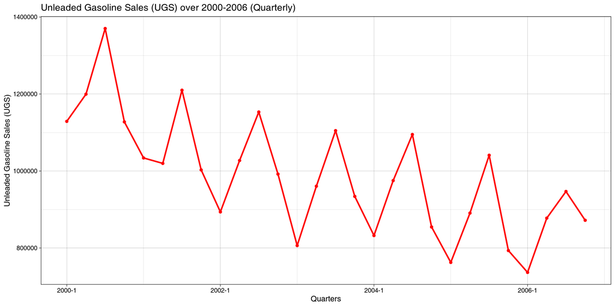

In the time series plot of UGS, there is a decreasing trend and an obvious seasonality for every year. In addition, the time series does not have stationary mean and variance. KPSS test is used to check the stationarity of the series. Since the test statistic is higher than critical values, the time series is **not stationary**.

```
##
## #######################
## # KPSS Unit Root Test #
## #######################
##
## Test is of type: mu with 2 lags.
##
## Value of test-statistic is: 0.8149
##
## Critical value for a significance level of:
##                 10pct  5pct 2.5pct  1pct
## critical values 0.347 0.463  0.574 0.739
```

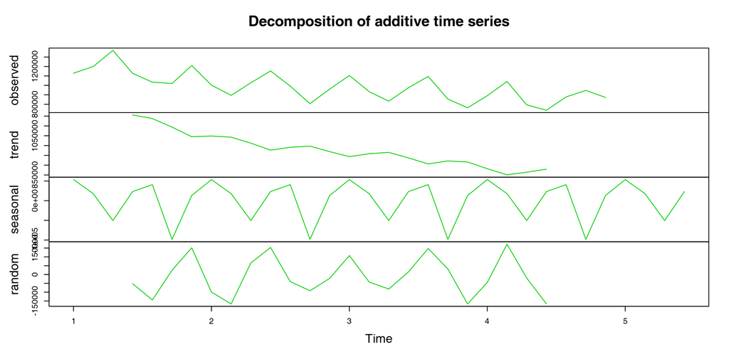

## 3. Autocorrelation Function of UGS

```
##
## Autocorrelations of series 'data$UGS[1:28]', by lag
##
##      0      1      2      3      4      5      6      7      8      9     10
##  1.000  0.481  0.041  0.296  0.605  0.150 -0.166  0.125  0.353 -0.001 -0.249
##     11     12     13     14
## -0.006  0.155 -0.107 -0.245
```

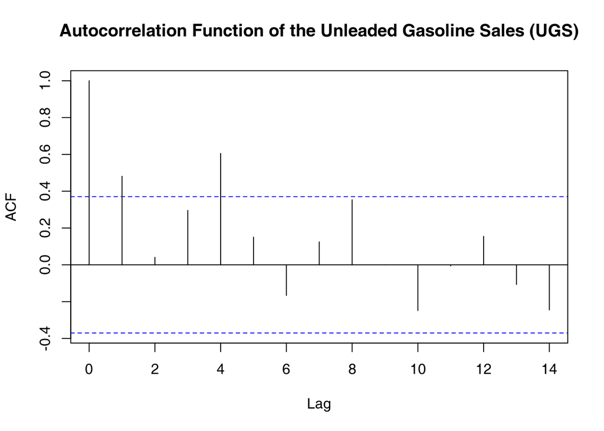

The time series is significantly autocorrelated on **lag 1 and 4**.

## 4. Model Selection

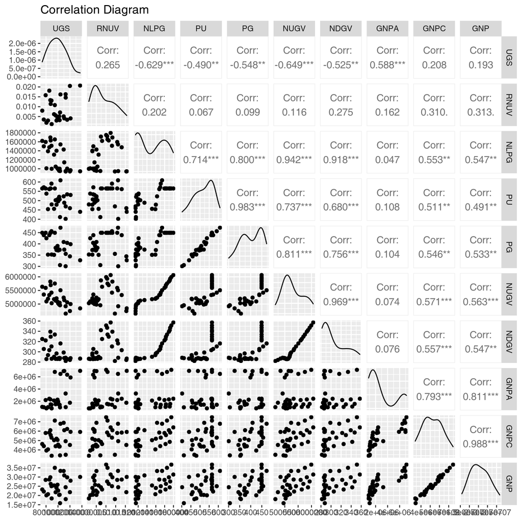

## 4.1. Alternative Model I

In correlation plots of UGS, there can be seen a significant correlation between UGS and other parameters NLPG, NUGV, GNPA. That is the reason why the regression modeling will start with those as predictors.

```
##
## Call:
## lm(formula = UGS ~ NLPG + NUGV + GNPA, data = data[1:28, ])
##
## Residuals:
##     Min      1Q  Median      3Q     Max
## -138411  -34379   -6271   38182  119783
##
## Coefficients:
##               Estimate Std. Error t value Pr(>|t|)
## (Intercept)  2.508e+06  4.602e+05   5.449 1.34e-05 ***
## NLPG        -4.578e-02  1.232e-01  -0.372   0.7134
## NUGV        -3.045e-01  1.151e-01  -2.645   0.0142 *
## GNPA         4.183e-02  5.735e-03   7.294 1.55e-07 ***
## ---
## Signif. codes:  0 '***' 0.001 '**' 0.01 '*' 0.05 '.' 0.1 ' ' 1
##
## Residual standard error: 67670 on 24 degrees of freedom
## Multiple R-squared:  0.8216, Adjusted R-squared:  0.7993
## F-statistic: 36.84 on 3 and 24 DF,  p-value: 3.827e-09
```

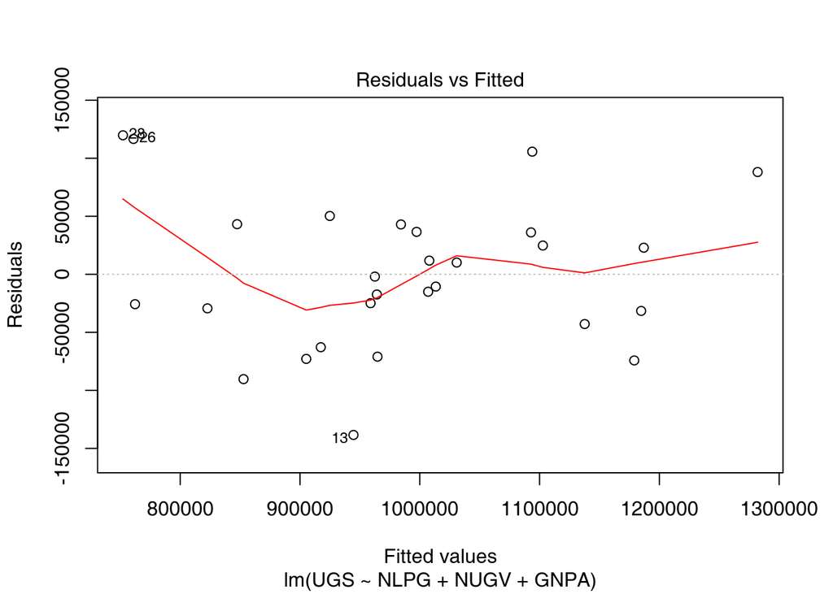

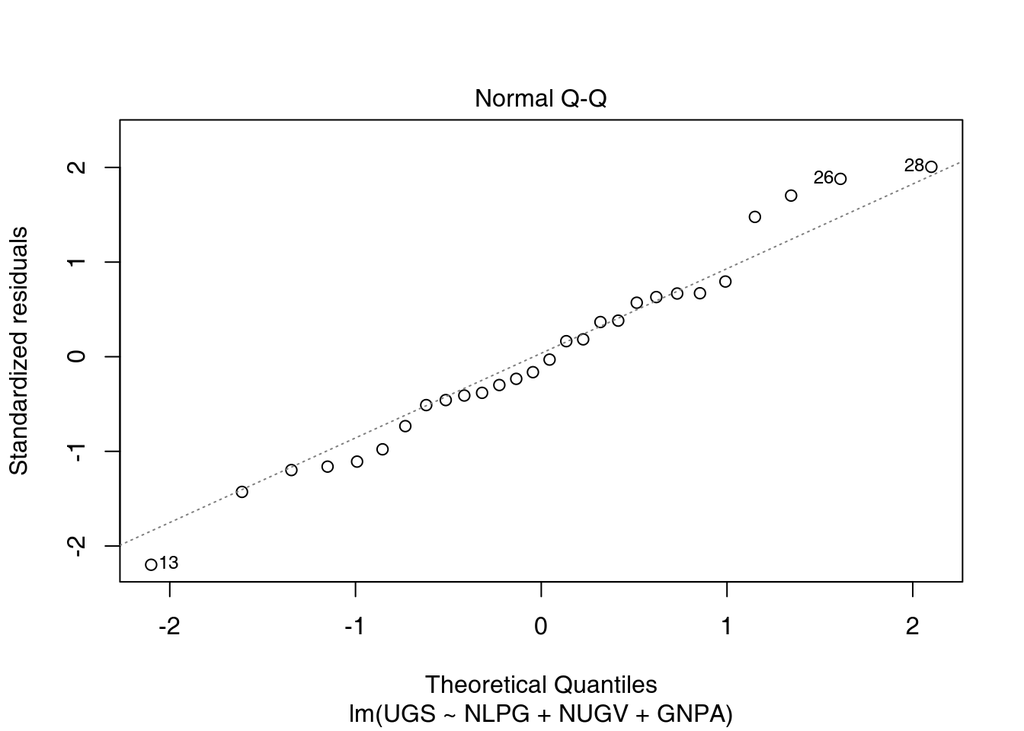

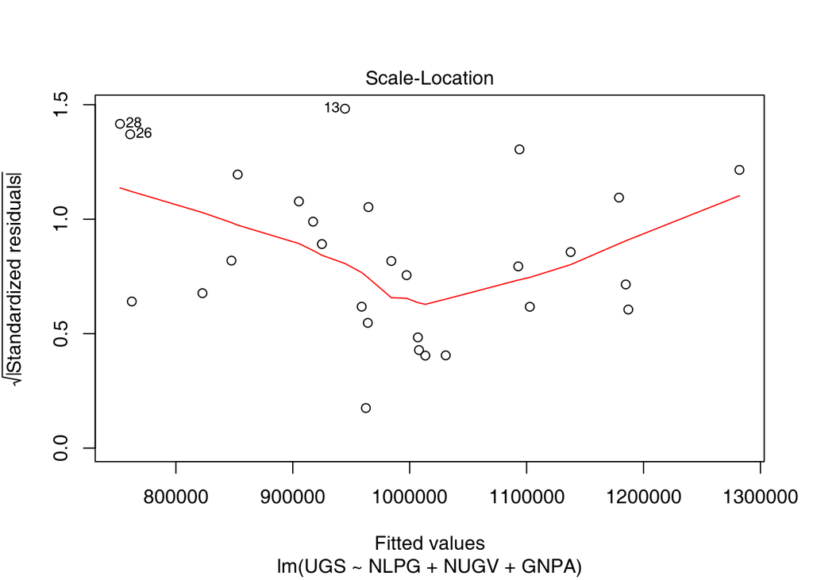

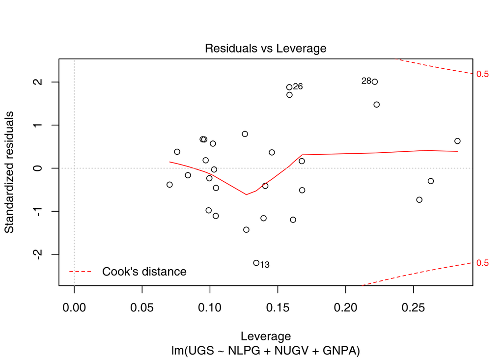

## 4.2. Alternative Model II

In this alternative model, trend and seasonality factors are added to the model. Those factors are defined and added to the data as “trend”, “season2”, “season3” and “season4” columns.

```
##    data...1. trend season2 season3 season4
## 1    2000 Q1     1       0       0       0
## 2    2000 Q2     2       1       0       0
## 3    2000 Q3     3       0       1       0
## 4    2000 Q4     4       0       0       1
## 5    2001 Q1     5       0       0       0
## 6    2001 Q2     6       1       0       0
## 7    2001 Q3     7       0       1       0
## 8    2001 Q4     8       0       0       1
## 9    2002 Q1     9       0       0       0
## 10   2002 Q2    10       1       0       0
## 11   2002 Q3    11       0       1       0
## 12   2002 Q4    12       0       0       1
## 13   2003 Q1    13       0       0       0
## 14   2003 Q2    14       1       0       0
```

[output cut: 18 more lines]

```
##
## Call:
## lm(formula = UGS ~ NLPG + NUGV + GNPA + trend + season2 + season3 +
##     season4, data = data[1:28, ])
##
## Residuals:
##    Min     1Q Median     3Q    Max
## -84890 -21290   -703  19074  84289
##
## Coefficients:
##               Estimate Std. Error t value Pr(>|t|)
## (Intercept)  5.121e+05  4.869e+05   1.052 0.305431
## NLPG         2.842e-01  9.798e-02   2.901 0.008837 **
## NUGV         6.281e-02  1.036e-01   0.606 0.551134
## GNPA         3.448e-02  2.826e-02   1.220 0.236594
## trend       -2.497e+04  4.839e+03  -5.160 4.76e-05 ***
## season2      1.081e+05  2.696e+04   4.012 0.000684 ***
## season3      8.513e+04  1.622e+05   0.525 0.605420
## season4      4.741e+04  4.545e+04   1.043 0.309336
## ---
## Signif. codes:  0 '***' 0.001 '**' 0.01 '*' 0.05 '.' 0.1 ' ' 1
##
## Residual standard error: 39820 on 20 degrees of freedom
## Multiple R-squared:  0.9485, Adjusted R-squared:  0.9305
## F-statistic: 52.64 on 7 and 20 DF,  p-value: 1.645e-11
```

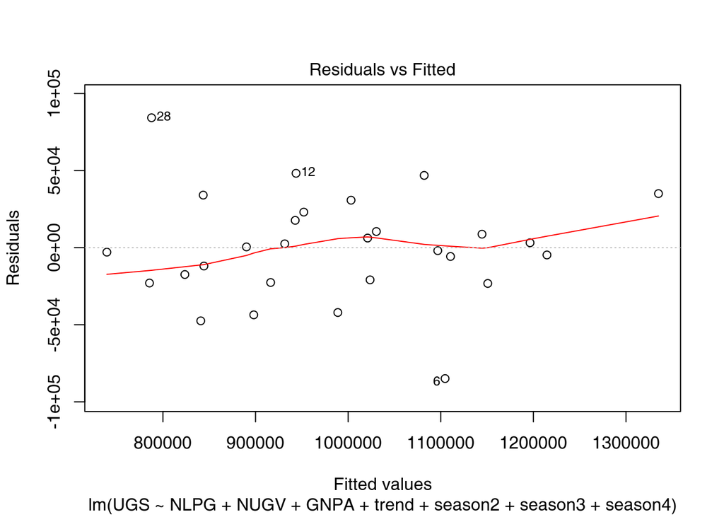

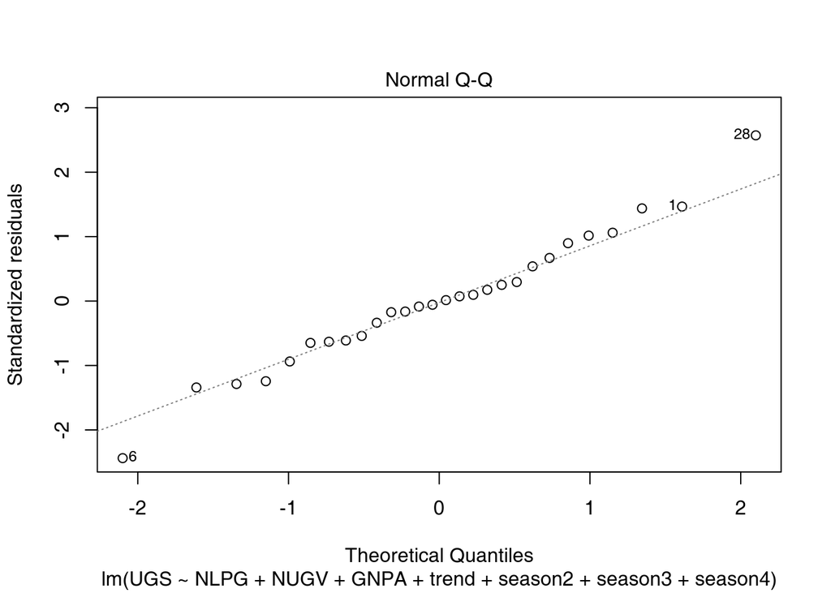

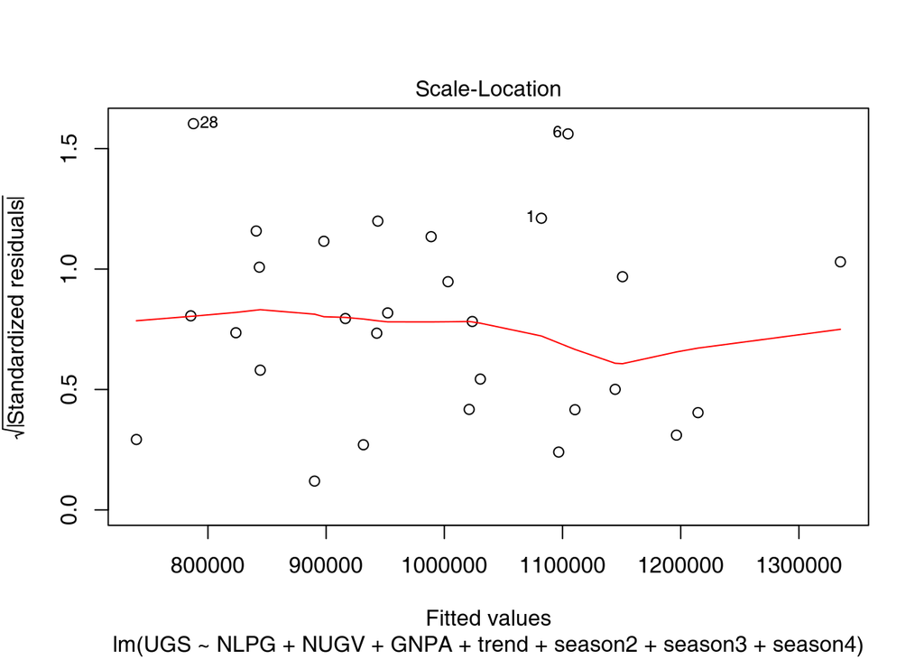

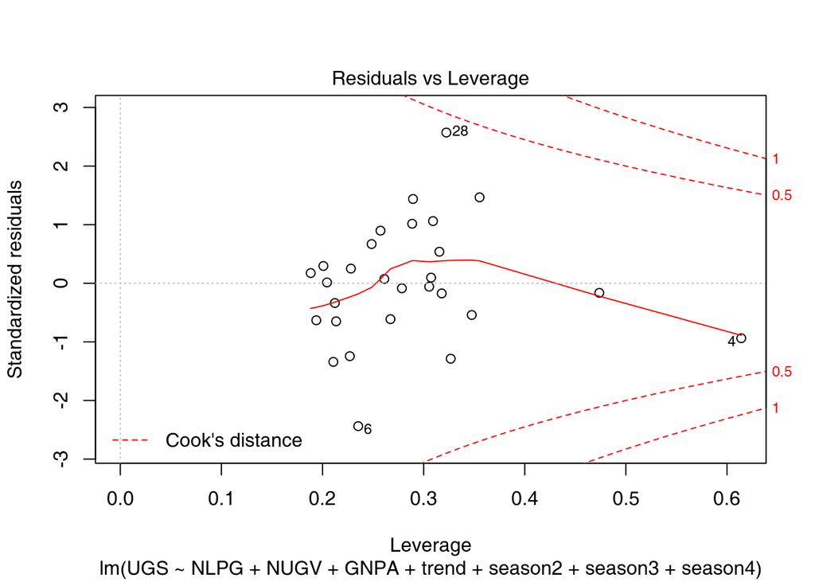

## 4.3. Alternative Model III

Since NUGV and GNPA are not significant to the model, they are removed from the model.

```
##
## Call:
## lm(formula = UGS ~ NLPG + trend + season2 + season3 + season4,
##     data = data[1:28, ])
##
## Residuals:
##    Min     1Q Median     3Q    Max
## -83022 -23287   3235  18555  90847
##
## Coefficients:
##               Estimate Std. Error t value Pr(>|t|)
## (Intercept)  8.082e+05  7.363e+04  10.977 2.16e-10 ***
## NLPG         3.259e-01  9.184e-02   3.549 0.001800 **
## trend       -2.422e+04  3.163e+03  -7.657 1.21e-07 ***
## season2      1.286e+05  2.128e+04   6.044 4.40e-06 ***
## season3      2.824e+05  2.140e+04  13.200 6.24e-12 ***
## season4      9.835e+04  2.137e+04   4.601 0.000139 ***
## ---
## Signif. codes:  0 '***' 0.001 '**' 0.01 '*' 0.05 '.' 0.1 ' ' 1
##
## Residual standard error: 39600 on 22 degrees of freedom
## Multiple R-squared:  0.944,  Adjusted R-squared:  0.9313
## F-statistic: 74.15 on 5 and 22 DF,  p-value: 5.077e-13
```

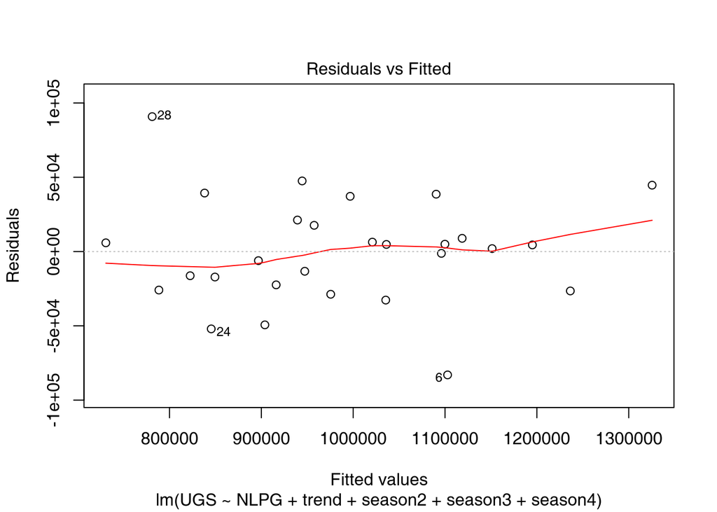

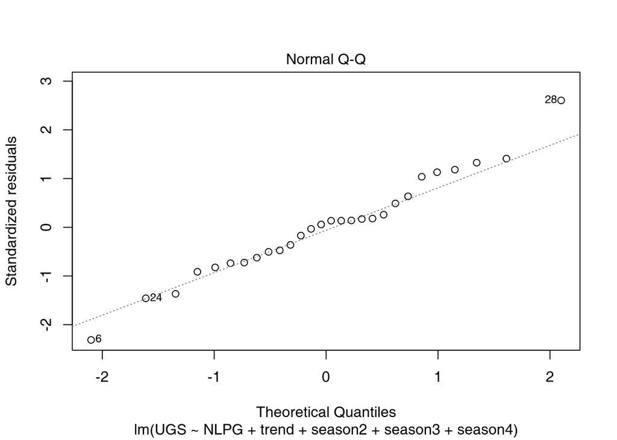

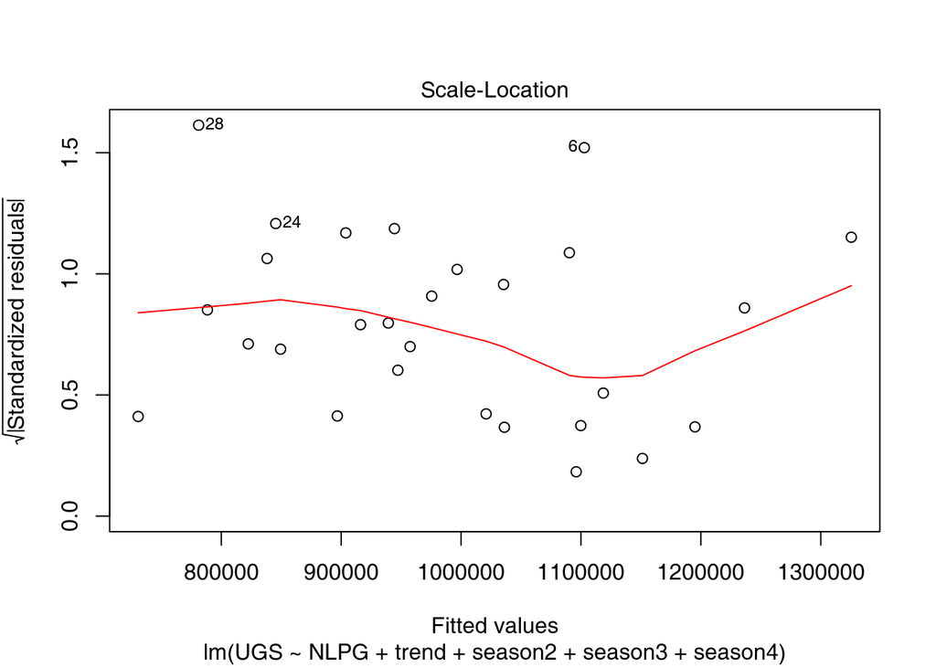

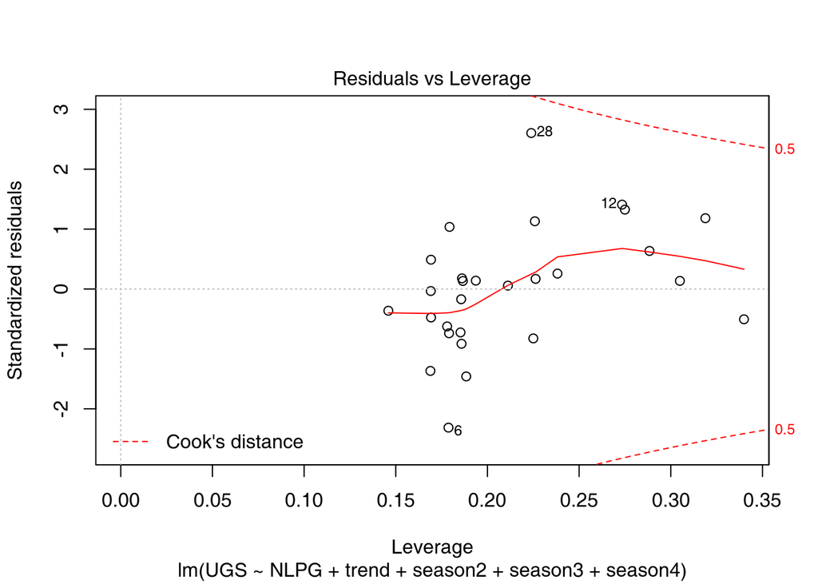

## 4.4. Alternative Model IV

UGS’s logarithm is taken to linearize it and used as target variable in the models. Likewise, variables with nonlinear increase can be included in the models as a predictor by taking the logarithm. In addition, data number 6, 12 and 28 are outliers and they are removed from the model. This is the best model because “Residual standard error” and “p-value” are close to 0, “Adjusted R-squared” is close to 1. **Alternative Model IV will be used in forecasting of UGS in 2007.**

[output not shown]

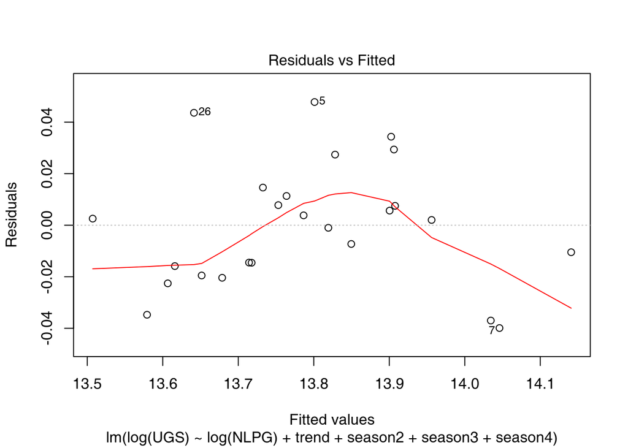

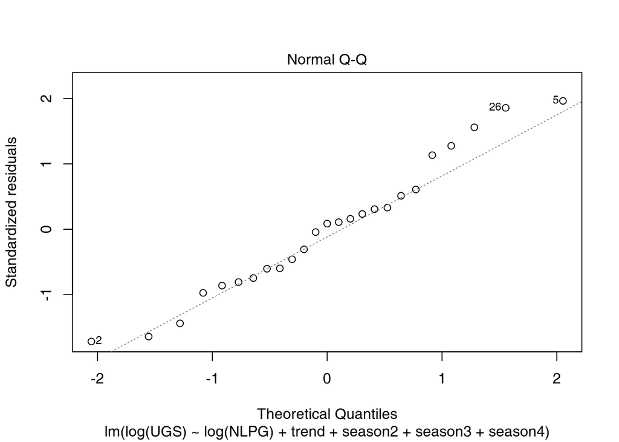

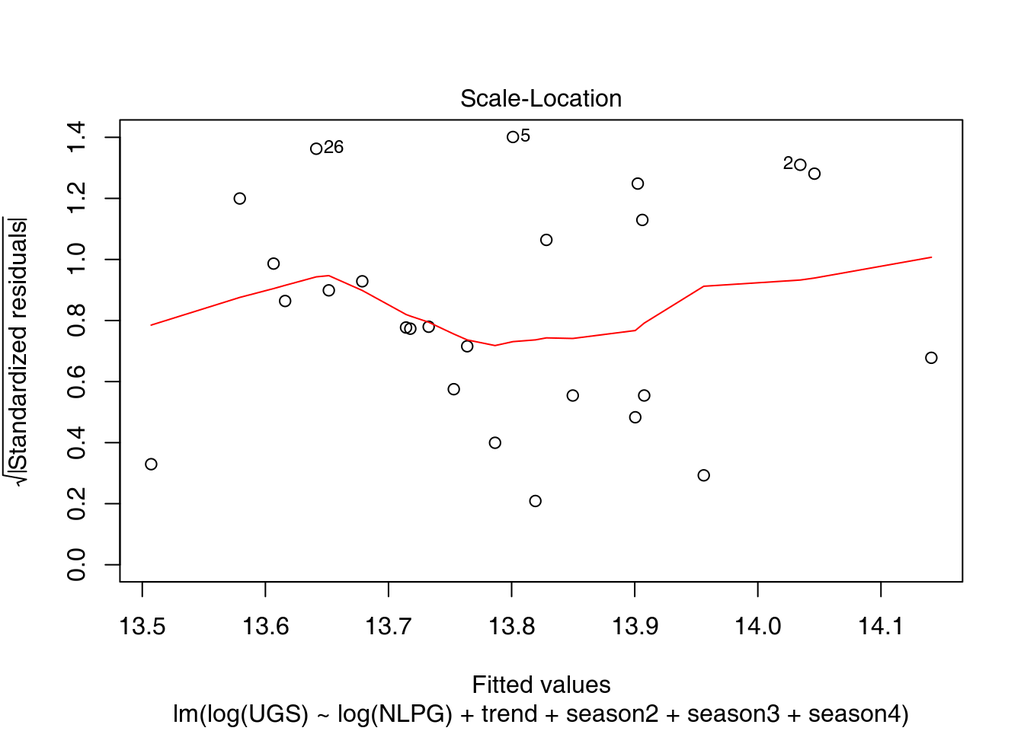

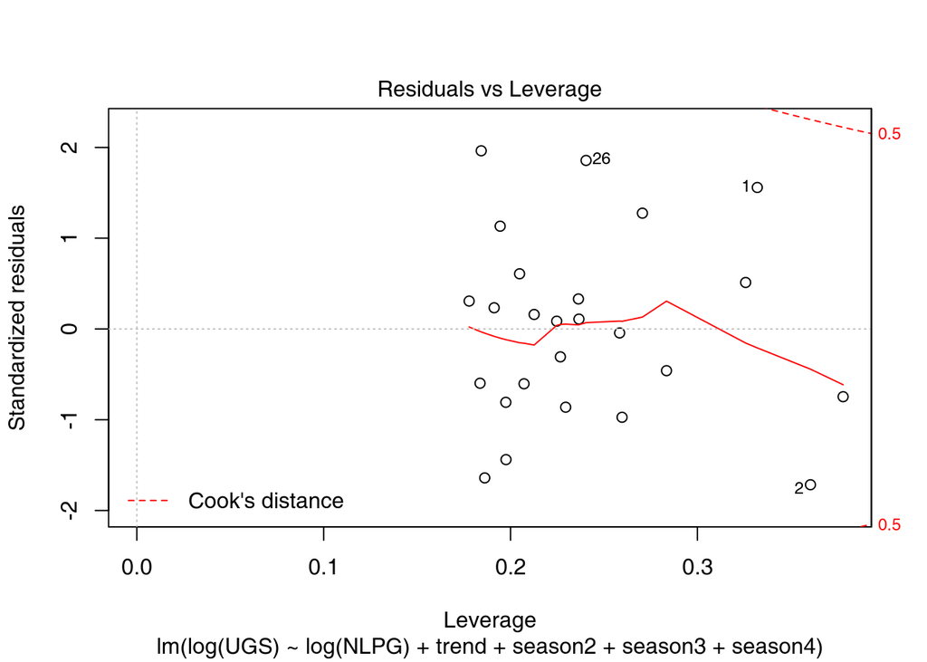

## 5. Model Validation

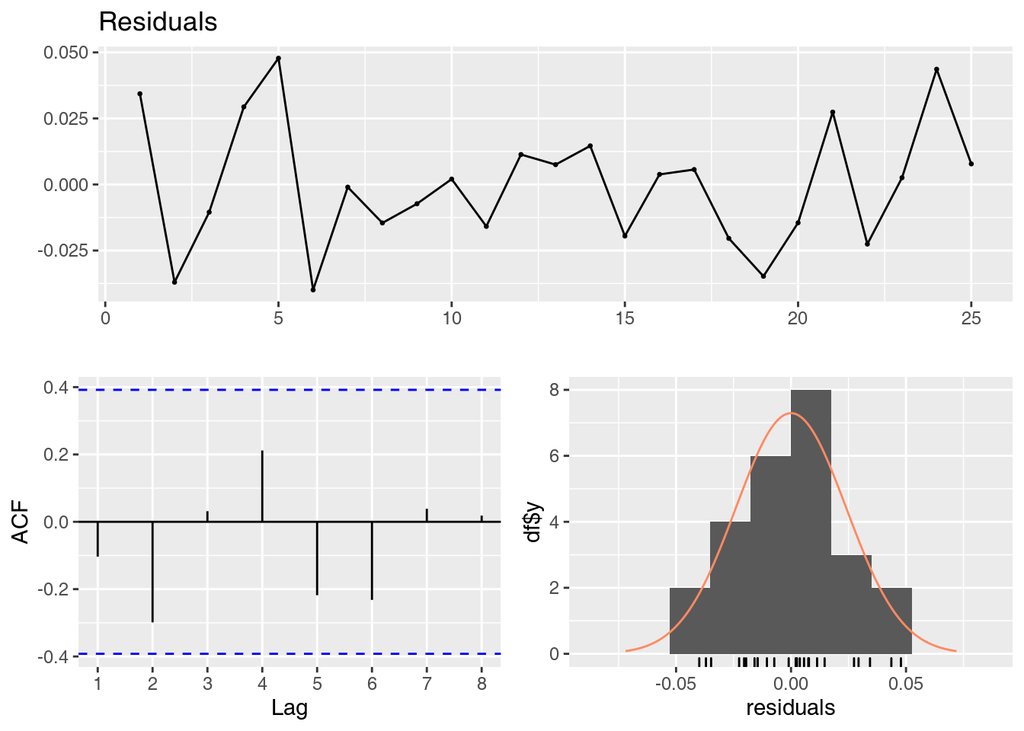

```
##
##  Breusch-Godfrey test for serial correlation of order up to 9
##
## data:  Residuals
## LM test = 14.025, df = 9, p-value = 0.1214
```

In residual analysis it can be seen that residuals are not autocorrelated and distributed normally. Also residuals scatter around mean zero and seem to have a constant variance. Thus this model satisfies the assumptions and it is good enough to use for the prediction of the next year’s quarterly sales.

## 6. Forecasts for Unleaded Gasoline Sales for 2007

```
##    data.Quarter data.UGS data.Prediction_UGS
## 1       2000 Q1  1128971           1090855.3
## 2       2000 Q2  1199569           1244783.3
## 3       2000 Q3  1370167           1384611.7
## 4       2000 Q4  1127548           1094912.6
## 5       2001 Q1  1033918            985660.7
## 6       2001 Q2  1019754           1126834.3
## 7       2001 Q3  1209916           1259178.8
## 8       2001 Q4  1002789           1003805.0
## 9       2002 Q1   893722            906831.8
## 10      2002 Q2  1027252           1034763.3
## 11      2002 Q3  1153265           1150918.8
## 12      2002 Q4   991981            910000.2
## 13      2003 Q1   806257            819153.6
## 14      2003 Q2   960556            949727.0
```

[output cut: 18 more lines]

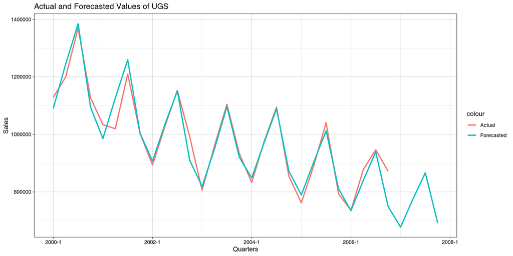

## 7. Conclusion

In conclusion, final forecasting model results are as follows.

```
## [1] "The predicted value of 2007-Quarter 1 :  677649.535449692"
```

```
## [1] "The predicted value of 2007-Quarter 2 :  774961.231185818"
```

```
## [1] "The predicted value of 2007-Quarter 3 :  866674.341249038"
```

```
## [1] "The predicted value of 2007-Quarter 4 :  691865.606409533"
```

## Additional Notes

My RMarkdown file is located at the progress journal. [Click here](https://bu-ie-360.github.io/spring22-BarisArslan/HW2/HW2_Baris_Arslan.Rmd)